# Flexible Damage Functions

Author

James Rising, Sebastian Cadavid Sanchez, Climate Impact Lab

Published

April 30, 2026

## 0.1 Labor: High Risk Country

Flexible damage function parameters at the Country level.

**Outcome units:** `portion` — dimensionless fraction of labor productivity for high risk workers, rebased to 2005 baseline; population-weighted aggregation to country

$$D_{it} = (\alpha_i T_t + \beta_i T_t^2) \cdot Y_{it}^{\gamma}$$

where $\gamma$ is the income elasticity (fitted globally), $\alpha_i$ is the linear coefficient, and $\beta_i$ is the quadratic coefficient.

# 1 Global Estimation

## 1.1 Income Elasticity Estimation

The income elasticity $\gamma$ is estimated using a fixed-effects regression:

$$y_{it} = \gamma \cdot \log(Y_{it}) + \mu_{g(i,T)} + \nu_t + \varepsilon_{it}$$

where $\mu_{g(i,T)}$ are region-by-temperature-bin fixed effects and $\nu_t$ are year fixed effects.

Table 1: Income Elasticity (Gamma) Estimation Results

| Statistic | Value |
| --- | --- |
| Income elasticity ($\gamma$) | -0.0443 |
| Standard error | 6.84e-03 |
| 95% CI | [-0.0577, -0.0309] |
| R-squared | 0.7109 |
| Observations | 79,181,550 |
| Regions | 245 |
| Gamma quantiles | 19 |

# 2 Parameter Distributions

## 2.1 8-Panel Summary

Row 1: gamma, alpha, beta, rsqr1. Row 2: rho, zeta, eta, rsqr2.

```
Using median gamma: -0.044339, 245 rows (of 4,655 total)
```

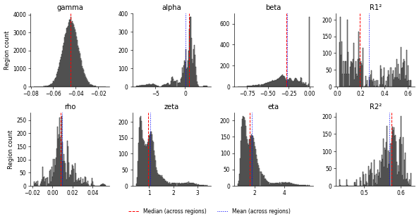

Figure 1: Distribution of Regional Parameters

## 2.2 Projection Equation and Parameter Definitions

The estimated parameters are used to project damages via Monte Carlo sampling:

$$D_{it}^k = (\hat{\alpha}_{ik} T_t + \hat{\beta}_{ik} T_t^2) Y_{it}^{\hat{\gamma}_k} + \hat{\theta}_{ik} T_t Y_{it}^{\hat{\gamma}_k} + \hat{\phi}_{it}^k$$

where $k$ indexes the Monte Carlo draw. The parameters in each row of the output CSV control distinct components of this equation:

- **gamma**: income elasticity $\hat{\gamma}_k$, one of 19 quantile values drawn from $N(\hat{\gamma}, SE(\hat{\gamma}))$
- **alpha, beta**: linear and quadratic temperature coefficients; $\hat{\alpha}_{ik}$ and $\hat{\beta}_{ik}$ are drawn from the joint normal defined by the VCV below
- **sigma11, sigma12, sigma22**: variance-covariance matrix of $(\alpha, \beta)$, used for joint uncertainty sampling
- **rho**: correlation between regional and global polynomial residuals $\rho_i$, used to maintain spatial covariance across regions in Monte Carlo draws
- **zeta**: temperature-dependent error scale $\zeta_{ik}$; the run-specific error term $\hat{\theta}_{ik}$ is drawn from $N(0, \zeta_{ik})$
- **eta**: residual noise standard deviation $\eta_{ik}$; the annual noise $\hat{\phi}_{it}^k$ is drawn from $N(0, \eta_{ik})$
- **rsqr1, rsqr2**: polynomial fit quality and error model fit, respectively

## 2.3 Summary Statistics

Table 2: Regional Parameter Summary

| Parameter | Mean | Median | Std | Min | Max | N |
| --- | --- | --- | --- | --- | --- | --- |
| alpha | 0.03037 | 0.6709 | 1.893 | -7.495 | 3.338 | 245 |
| beta | -0.2628 | -0.2766 | 0.1784 | -0.7623 | 0 | 245 |
| rho | 0.009913 | 0.008634 | 0.01091 | -0.01794 | 0.05065 | 245 |
| zeta | 1.052 | 0.9823 | 0.4813 | 0.5081 | 3.078 | 245 |
| eta | 1.813 | 1.679 | 0.7453 | 0.9384 | 5.144 | 245 |
| rsqr1 | 0.2665 | 0.1922 | 0.1969 | 0.0197 | 0.6275 | 245 |
| rsqr2 | 0.5687 | 0.5744 | 0.03278 | 0.4338 | 0.6281 | 245 |

# 3 Spaghetti Curves

Regional damage function curves showing D(T) = αT + βT² for sampled regions.

[interactive chart not shown]

Figure 2: Regional Damage Functions

# 4 Zero Crossings

The zero crossing (extremum) of the parabola occurs at $T^* = -\alpha / (2\beta)$.

Table 3: Zero Crossing Statistics

| Category | Count | Percentage |
| --- | --- | --- |
| β = 0 (no crossing) | 31 | 12.7% |
| T > 20°C (beyond graph) | 6 | 2.4% |
| T < 0°C (negative crossing) | 76 | 31.0% |
| Valid crossings (0-20°C) | 132 | 53.9% |

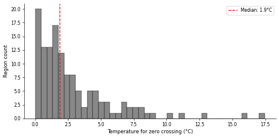

Figure 3: Distribution of Zero Crossing Temperatures

# 5 Slope Analysis

Maximum slope between 0 and 10°C: $\frac{dM}{dT} = \alpha + 2\beta T$

The maximum occurs at either T=0 or T=10 (endpoints of interval).

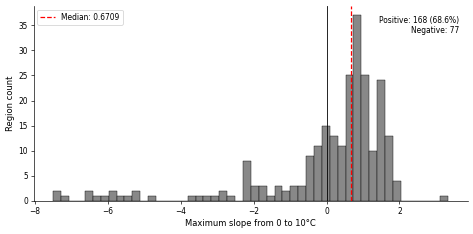

Figure 4: Distribution of Maximum Slopes (0-10°C)

*Convexity analysis omitted (beta constraint active).*

# 6 R-squared Analysis

## 6.1 Polynomial Fit Quality (rsqr1)

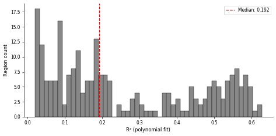

Figure 5: Regional Fit Quality (R-squared)

## 6.2 Error Model R-squared (rsqr2) Quantiles

Table 4: rsqr2 Quantiles

| 0% (Min) | 25% | 50% (Median) | 75% | 100% (Max) |
| --- | --- | --- | --- | --- |
| 0.4338 | 0.5526 | 0.5744 | 0.5922 | 0.6281 |

# 7 Modelled Variance

Modelled variance statistic: $1 - \frac{\sum_i \eta_i^2}{\sum_i D_i^2}$

Table 5: Modelled Variance Statistics

| Statistic | Value |
| --- | --- |
| Modelled variance | 0.9124 |
| Sum(η²) | 940.9441 |
| Sum(D²) at T=3.0°C | 10746.1280 |
| N regions | 245 |

# 8 Best- and Worst-Fitting Regions

The 3 worst- and 3 best-fitting regions by R-squared, with raw simulation data overlaid on the fitted polynomial curve. **Red rows = worst fits**, **green rows = best fits**.

Table 6: Best- and worst-fitting regions

Top 3 best fit (R²) Top 3 worst fit (R²)

| Region | α | β | η | R² |
| --- | --- | --- | --- | --- |
| SEN | -3.49 | -0.356 | 2.57 | 0.627 |
| GMB | -3.62 | -0.352 | 2.68 | 0.621 |
| CUW | -1.69 | -0.593 | 2.34 | 0.609 |
| KAZ | 1.05 | -0.277 | 2.01 | 0.0197 |
| KGZ | 1.49 | -0.337 | 2.04 | 0.0222 |
| PER | 0.91 | -0.226 | 1.44 | 0.0226 |

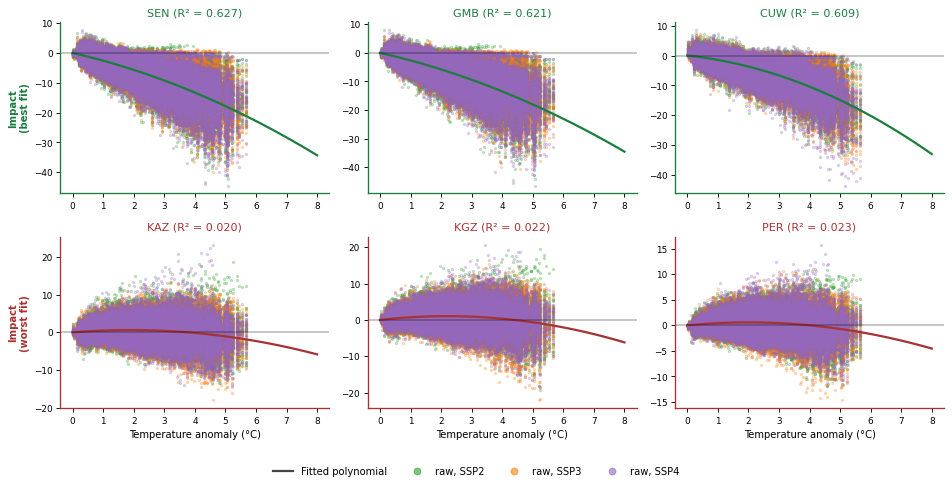

# 9 Regional Parameter Maps

Maps of key parameters at the **country** level. Red = negative (damage increases with T), Blue = positive.

## 9.1 Alpha (Linear Coefficient)

Alpha ($\alpha$) represents the linear sensitivity to temperature. Regions with negative alpha experience damage that increases with the first degree of warming.

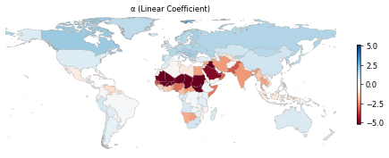

Figure 7: α (linear coefficient)

## 9.2 Beta (Quadratic Coefficient)

Beta ($\beta$) represents the curvature of the damage function.

The concavity ($\beta \leq 0$) constraint is enforced for this sector, meaning optimal temperature exists, damages accelerate beyond it.

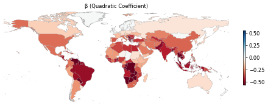

Figure 8: β (quadratic coefficient)

## 9.3 R-squared (Fit Quality)

$R^2$ measures the polynomial fit quality. Higher values indicate that the quadratic form captures more of the variance in the data.

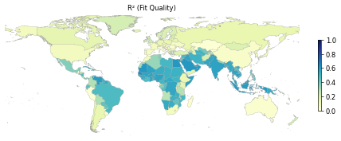

Figure 9: R² (stage 1 fit quality)

# 10 F2: Flex vs Raw Comparison

Comparison of flexible damage function predictions against raw simulation means.

For each scenario (RCP × SSP × Model), we compute at the final year:

- **Flex predicted**: $(\alpha \cdot T + \beta \cdot T^2) \cdot Y^\gamma$
- **Raw actual**: The outcome variable (y) from the source data

**Year 2099**: 1,480,050 rows

**rcp45**

**SSP2**

**high**

**Correlation:** 0.9755 | **RMSE:** 1.353961 | **Sign agreement:** 85.7%

[interactive chart not shown]

Top 5 best predicted Top 5 worst predicted

Year 2099 · T<sub>mean</sub> across these regions: 1.96°C

| Region | Raw | Flex | Residual |
| --- | --- | --- | --- |
| CA- | -0.226 | -0.233 | -0.00739 |
| ETH | -0.26 | -0.25 | 0.0101 |
| COL | -0.553 | -0.566 | -0.0129 |
| KIR | -0.5 | -0.529 | -0.0288 |
| ATG | -0.411 | -0.448 | -0.0371 |
| QAT | -2.35 | -7.1 | -4.75 |
| SSD | -2.64 | -7.29 | -4.66 |
| SDN | -4.68 | -9.21 | -4.53 |
| ARE | -2.36 | -6.81 | -4.45 |
| KWT | -3.5 | -7.78 | -4.28 |

**low**

**Correlation:** 0.9697 | **RMSE:** 1.252732 | **Sign agreement:** 82.9%

[interactive chart not shown]

Top 5 best predicted Top 5 worst predicted

Year 2099 · T<sub>mean</sub> across these regions: 1.96°C

| Region | Raw | Flex | Residual |
| --- | --- | --- | --- |
| BRB | -0.475 | -0.468 | 0.00722 |
| AFG | -0.81 | -0.803 | 0.00774 |
| LBN | -0.474 | -0.49 | -0.0165 |
| JAM | -0.379 | -0.407 | -0.0277 |
| YEM | -0.472 | -0.507 | -0.0352 |
| QAT | -2.36 | -7.1 | -4.74 |
| ARE | -2.36 | -6.81 | -4.46 |
| SSD | -3.02 | -7.43 | -4.42 |
| SDN | -5.37 | -9.45 | -4.08 |
| KWT | -4.07 | -7.93 | -3.87 |

**SSP3**

**high**

**Correlation:** 0.9742 | **RMSE:** 1.162456 | **Sign agreement:** 85.3%

[interactive chart not shown]

Top 5 best predicted Top 5 worst predicted

Year 2099 · T<sub>mean</sub> across these regions: 1.96°C

| Region | Raw | Flex | Residual |
| --- | --- | --- | --- |
| ZWE | -0.925 | -0.919 | 0.00647 |
| TJK | -1.32 | -1.33 | -0.0151 |
| LBR | -1.17 | -1.19 | -0.0191 |
| NPL | -1.03 | -1.01 | 0.0197 |
| YEM | -0.57 | -0.545 | 0.0246 |
| QAT | -2.64 | -7.17 | -4.53 |
| SSD | -3.41 | -7.53 | -4.12 |
| ARE | -2.93 | -6.99 | -4.06 |
| KWT | -4 | -7.95 | -3.95 |
| SDN | -6.32 | -9.77 | -3.45 |

**low**

**Correlation:** 0.9647 | **RMSE:** 1.091163 | **Sign agreement:** 88.6%

[interactive chart not shown]

Top 5 best predicted Top 5 worst predicted

Year 2099 · T<sub>mean</sub> across these regions: 1.96°C

| Region | Raw | Flex | Residual |
| --- | --- | --- | --- |
| ETH | -0.292 | -0.293 | -8.65e-4 |
| BRB | -0.485 | -0.481 | 0.00405 |
| PHL | -0.948 | -0.943 | 0.00496 |
| NPL | -1.06 | -1.06 | -0.00537 |
| CA- | -0.234 | -0.245 | -0.0114 |
| QAT | -2.5 | -7.17 | -4.67 |
| ARE | -2.75 | -6.99 | -4.23 |
| SSD | -3.52 | -7.66 | -4.14 |
| KWT | -4.14 | -7.99 | -3.85 |
| BHR | -3.65 | -7.34 | -3.69 |

**SSP4**

**high**

**Correlation:** 0.9549 | **RMSE:** 1.233016 | **Sign agreement:** 84.9%

[interactive chart not shown]

Top 5 best predicted Top 5 worst predicted

Year 2099 · T<sub>mean</sub> across these regions: 1.96°C

| Region | Raw | Flex | Residual |
| --- | --- | --- | --- |
| COL | -0.564 | -0.568 | -0.00427 |
| YEM | -0.558 | -0.549 | 0.00885 |
| GAB | -0.401 | -0.389 | 0.0115 |
| PHL | -0.908 | -0.922 | -0.0147 |
| LBR | -1.23 | -1.21 | 0.018 |
| QAT | -2.28 | -7.07 | -4.79 |
| KWT | -3.19 | -7.7 | -4.5 |
| ARE | -2.29 | -6.79 | -4.5 |
| SSD | -3.03 | -7.45 | -4.42 |
| BHR | -3.51 | -7.26 | -3.75 |

**low**

**Correlation:** 0.9669 | **RMSE:** 1.137299 | **Sign agreement:** 84.1%

[interactive chart not shown]

Top 5 best predicted Top 5 worst predicted

Year 2099 · T<sub>mean</sub> across these regions: 1.96°C

| Region | Raw | Flex | Residual |
| --- | --- | --- | --- |
| JAM | -0.421 | -0.414 | 0.00656 |
| BRA | -1.09 | -1.08 | 0.0125 |
| PHL | -0.942 | -0.921 | 0.0206 |
| LAO | -1.72 | -1.75 | -0.0211 |
| YEM | -0.493 | -0.521 | -0.0281 |
| QAT | -2.24 | -7.07 | -4.83 |
| ARE | -2.26 | -6.79 | -4.53 |
| SSD | -3.46 | -7.6 | -4.14 |
| KWT | -4.44 | -8.08 | -3.63 |
| BHR | -3.9 | -7.4 | -3.5 |

**rcp85**

**SSP2**

**high**

**Correlation:** 0.9598 | **RMSE:** 2.439920 | **Sign agreement:** 80.4%

[interactive chart not shown]

Top 5 best predicted Top 5 worst predicted

Year 2099 · T<sub>mean</sub> across these regions: 4.20°C

| Region | Raw | Flex | Residual |
| --- | --- | --- | --- |
| VIR | -1.09 | -1.09 | -0.00447 |
| GLP | -1.02 | -0.993 | 0.0267 |
| CYM | -1.39 | -1.35 | 0.0382 |
| MSR | -0.999 | -0.931 | 0.0677 |
| SYC | -1.11 | -1.04 | 0.0737 |
| QAT | -9.06 | -17.1 | -8.08 |
| ARE | -8.7 | -16.4 | -7.66 |
| BWA | -5.82 | -12.6 | -6.82 |
| KWT | -12.5 | -18.8 | -6.31 |
| SSD | -10.5 | -16.6 | -6.01 |

**low**

**Correlation:** 0.9536 | **RMSE:** 2.198130 | **Sign agreement:** 82.0%

[interactive chart not shown]

Top 5 best predicted Top 5 worst predicted

Year 2099 · T<sub>mean</sub> across these regions: 4.20°C

| Region | Raw | Flex | Residual |
| --- | --- | --- | --- |
| TUV | -1.36 | -1.36 | -0.00942 |
| COL | -3.04 | -3.01 | 0.0268 |
| AFG | -3.44 | -3.47 | -0.0297 |
| FSM | -1.56 | -1.61 | -0.0433 |
| VIR | -1.18 | -1.11 | 0.0733 |
| QAT | -8.73 | -17.1 | -8.41 |
| ARE | -8.47 | -16.4 | -7.89 |
| BWA | -5.89 | -12.7 | -6.77 |
| BHR | -11.6 | -17.6 | -6 |
| KWT | -13.5 | -19.2 | -5.67 |

**SSP3**

**high**

**Correlation:** 0.9605 | **RMSE:** 2.082239 | **Sign agreement:** 86.9%

[interactive chart not shown]

Top 5 best predicted Top 5 worst predicted

Year 2099 · T<sub>mean</sub> across these regions: 4.20°C

| Region | Raw | Flex | Residual |
| --- | --- | --- | --- |
| TUV | -1.35 | -1.38 | -0.0323 |
| BOL | -3.79 | -3.82 | -0.0373 |
| COL | -3.01 | -3.05 | -0.0471 |
| VIR | -1.17 | -1.13 | 0.0486 |
| FSM | -1.57 | -1.63 | -0.0602 |
| QAT | -8.79 | -17.3 | -8.53 |
| ARE | -9.41 | -16.8 | -7.36 |
| KWT | -12.7 | -19.2 | -6.5 |
| BWA | -6.91 | -13 | -6.12 |
| BHR | -12.8 | -18.1 | -5.28 |

**low**

**Correlation:** 0.9531 | **RMSE:** 1.977722 | **Sign agreement:** 84.9%

[interactive chart not shown]

Top 5 best predicted Top 5 worst predicted

Year 2099 · T<sub>mean</sub> across these regions: 4.20°C

| Region | Raw | Flex | Residual |
| --- | --- | --- | --- |
| ZMB | -7.48 | -7.48 | 8.78e-4 |
| TLS | -1.36 | -1.33 | 0.0341 |
| CRI | -2.19 | -2.13 | 0.0583 |
| HTI | -4.84 | -4.78 | 0.0595 |
| ARM | -1.79 | -1.72 | 0.0627 |
| QAT | -9.16 | -17.3 | -8.15 |
| ARE | -9.74 | -16.8 | -7.04 |
| BWA | -6.88 | -12.9 | -6.06 |
| KWT | -13.6 | -19.3 | -5.65 |
| BHR | -12.2 | -17.9 | -5.63 |

**SSP4**

**high**

**Correlation:** 0.9422 | **RMSE:** 2.254471 | **Sign agreement:** 81.2%

[interactive chart not shown]

Top 5 best predicted Top 5 worst predicted

Year 2099 · T<sub>mean</sub> across these regions: 4.20°C

| Region | Raw | Flex | Residual |
| --- | --- | --- | --- |
| TUV | -1.38 | -1.37 | 0.0152 |
| FSM | -1.59 | -1.61 | -0.0156 |
| ZWE | -5.51 | -5.49 | 0.0161 |
| MMR | -8.71 | -8.68 | 0.0263 |
| BEN | -12.9 | -13 | -0.0461 |
| QAT | -8.4 | -17.1 | -8.67 |
| ARE | -8.18 | -16.3 | -8.12 |
| KWT | -11.2 | -18.6 | -7.43 |
| BWA | -5.79 | -12.6 | -6.85 |
| BHR | -11.7 | -17.7 | -5.92 |

**low**

**Correlation:** 0.9559 | **RMSE:** 1.906705 | **Sign agreement:** 86.9%

[interactive chart not shown]

Top 5 best predicted Top 5 worst predicted

Year 2099 · T<sub>mean</sub> across these regions: 4.20°C

| Region | Raw | Flex | Residual |
| --- | --- | --- | --- |
| TUV | -1.41 | -1.39 | 0.0184 |
| ARM | -1.71 | -1.74 | -0.0209 |
| GNB | -12.5 | -12.5 | -0.023 |
| LKA | -3.34 | -3.36 | -0.026 |
| CRI | -2.16 | -2.13 | 0.0274 |
| QAT | -8.61 | -17.1 | -8.46 |
| ARE | -8.48 | -16.3 | -7.82 |
| BWA | -7.06 | -13 | -5.91 |
| BHR | -13.2 | -18 | -4.82 |
| KWT | -14.9 | -19.5 | -4.61 |

## 10.1 Scenario Summary

Table 7: Fit statistics across all 12 scenarios

| RCP | SSP | Model | N | Corr | RMSE | Sign% |
| --- | --- | --- | --- | --- | --- | --- |
| rcp45 | SSP2 | high | 245 | 0.9755 | 1.35396 | 85.7% |
| rcp45 | SSP2 | low | 245 | 0.9697 | 1.25273 | 82.9% |
| rcp45 | SSP3 | high | 245 | 0.9742 | 1.16246 | 85.3% |
| rcp45 | SSP3 | low | 245 | 0.9647 | 1.09116 | 88.6% |
| rcp45 | SSP4 | high | 245 | 0.9549 | 1.23302 | 84.9% |
| rcp45 | SSP4 | low | 245 | 0.9669 | 1.1373 | 84.1% |
| rcp85 | SSP2 | high | 245 | 0.9598 | 2.43992 | 80.4% |
| rcp85 | SSP2 | low | 245 | 0.9536 | 2.19813 | 82.0% |
| rcp85 | SSP3 | high | 245 | 0.9605 | 2.08224 | 86.9% |
| rcp85 | SSP3 | low | 245 | 0.9531 | 1.97772 | 84.9% |
| rcp85 | SSP4 | high | 245 | 0.9422 | 2.25447 | 81.2% |
| rcp85 | SSP4 | low | 245 | 0.9559 | 1.90671 | 86.9% |

# 11 Data Reference

## 11.1 File Locations

| Item | Path |
| --- | --- |
| Regional CSV | `/project/cil/gcp/flex_damage_funcs/parameters/labor__high_risk_country__regional_parameters.csv` |
| Global JSON | `/project/cil/gcp/flex_damage_funcs/parameters/labor__high_risk_country__global_results.json` |
| Metadata JSON | `/project/cil/gcp/flex_damage_funcs/parameters/labor__high_risk_country__metadata.json` |

## 11.2 Column Definitions

| Column | Description |
| --- | --- |
| `region` | Region identifier (hierarchical code, first 3 chars = country ISO3) |
| `gamma` | Income elasticity quantile value |
| `alpha` | Linear temperature coefficient |
| `beta` | Quadratic temperature coefficient |
| `sigma11` | Var(alpha) |
| `sigma12` | Cov(alpha, beta) |
| `sigma22` | Var(beta) |
| `rho` | Correlation with global residual process |
| `zeta` | Temperature-dependent heteroskedasticity |
| `eta` | Residual standard deviation |
| `rsqr1` | R-squared of polynomial fit |
| `rsqr2` | R-squared of error model |

*Report generated with FlexDamage v1.0.0*